# Downstream Analysis Notebook

## Normalization, feature selection and scaling

### Normalization

To start this section I apply normalization to the expression values cells can be compared. Each value is divided by the total expression in its cell, multiplied by a scale factor and then log transformed.

$$N_{ij}=log(1+M\frac{A_{ij}}{\sum_{j'}A_{ij'}}) \\
M=10⁴$$

```r
seurat.obj.filtered<-NormalizeData(object=seurat.obj.filtered)
```

### Highly variable features

Next, I select the genes with high standarized log dispersion. The log dispersion $d$ of a gene $i$ with mean and variance standarized expresion $v_i,m_i$ is simply:

$$d_i = log(v_i/m_i)$$

```r
seurat.obj.filtered <-
  FindVariableFeatures(
    object = seurat.obj.filtered,
    mean.cutoff = c(0.5, Inf),
    dispersion.cutoff = c(0.1, Inf)
  )
```

### Scale data

Through `ScaleData()` I shift the expression of each gene, so that the mean expression across cells is 0 and scales the expression of each gene, so that the variance across cells is 1. This step gives equal weight in downstream analyses, so that highly-expressed genes do not dominate and is a required step prior to dimensional reduction techniques.

$$X{ij}=(N_{ij}-\mu_i)/\sigma_i$$

```r
seurat.obj.filtered <-
  ScaleData(seurat.obj.filtered,
            vars.to.regress = c("nCount_RNA",  "percent.mt"))
```

## Dimension reduction

### Principal Component Analysis

I run the analysis with `RunPCA()` over the selected most variable genes and then project the dimensional reduction (with `ProjectDim`) onto the entire dataset so that all genes have loadings.

```r
seurat.obj.filtered <-
  RunPCA(
    seurat.obj.filtered,
    features = VariableFeatures(seurat.obj.filtered),
    ndims.print = 1
  )
seurat.obj.filtered <- ProjectDim(seurat.obj.filtered, verbose = F)
```

After PCA, to keep enough PC’s to capture most of the variation I check the standard deviation of each PC and I keep those before the Elbow that appears in the plot. The PC kept will be used for clustering and t-SNE.

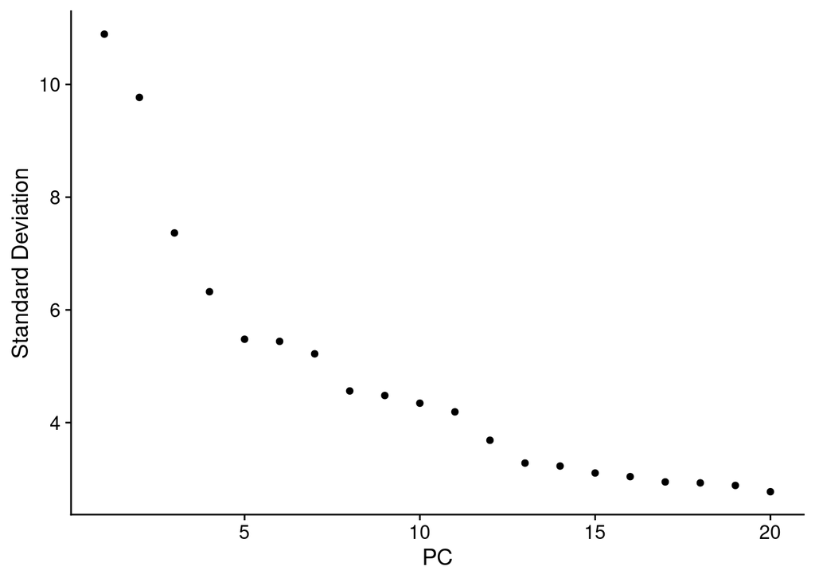

```r
ElbowPlot(seurat.obj.filtered)
```

*Chose in the next chunk the number of PC to be kept*

```r
n.pcs <- 13
```

### Shared Nearest Neighbor Clustering

To obtain the cluster, first, I compute the 30 nearest neighbors according in the dimensional space set by the selected PC with `FindNeighbours`. Then the clusters are identified through shared nearest neighbors with `FindClusters` and finally ploted through `DimPlot`.

```r
seurat.obj.filtered <-
  FindNeighbors(seurat.obj.filtered,
                dims = 1:n.pcs,
                k.param = 30)
seurat.obj.filtered <-
  FindClusters(
    seurat.obj.filtered,
    resolution = 0.1,
    random.seed = 42,
    n.start = 20,
    n.iter = 20
  )
```

```
## Modularity Optimizer version 1.3.0 by Ludo Waltman and Nees Jan van Eck
##
## Number of nodes: 580
## Number of edges: 18107
##
## Running Louvain algorithm...
## Maximum modularity in 20 random starts: 0.9655
## Number of communities: 8
## Elapsed time: 0 seconds
```

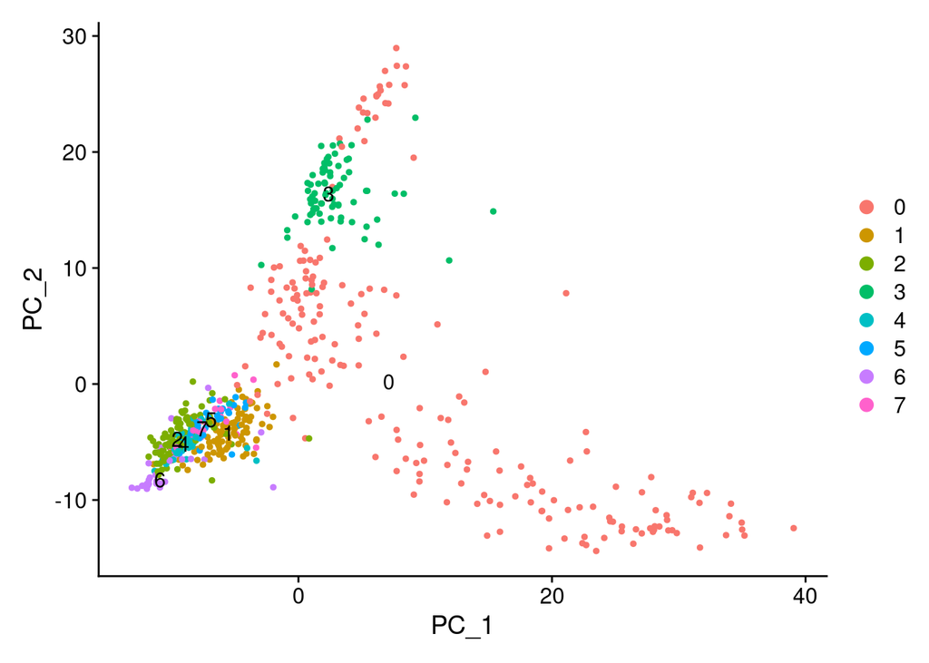

```r
DimPlot(
  seurat.obj.filtered ,
  dims = c(1, 2),
  reduction = "pca",
  label = TRUE
)
```

### t-Distributed Stochastic Neighbor Embedding dimensional reduction

For our application, we will use Seurat’s `RunTSNE`. It does not work directly on the genes as dimensions as t-SNE struggles with too many dimensions. It uses the principal components computed above, since PC are good at separating signal from noise. We need to choose a parameter named perplexity that roughly sets how much impact closer points have over points further apart.

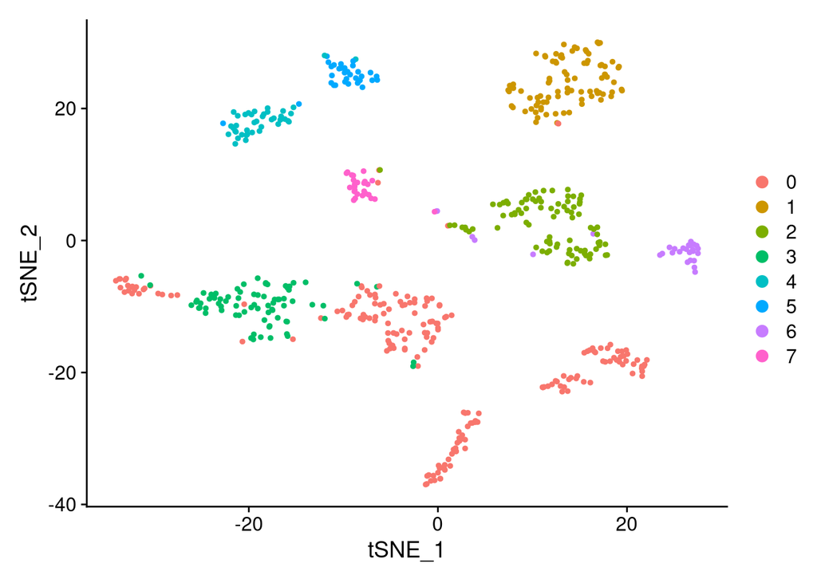

```r
seurat.obj.filtered <-
  RunTSNE(
    seurat.obj.filtered,
    dims.use = 1:n.pcs,
    seed.use = 42,
    perplexity = 15,
    dim.embed = 2
  )
TSNEPlot(seurat.obj.filtered)
```

## Differential expression

The differential expression analysis can be performed with `FindAllMarkers`. This function provides a table detailing the marker genes of each cluster. Including its id, the cluster in which it is differentially expressed, the difference in expression and the metric used to find the markers. The metric used is the area under the curve (AUC). To compute it, the function builds a classifier for each combination of gene and cluster, with that gene as the only classifier and a with the cluster and the rest of cells as the two classes. To evaluate the classifier, `FindAllMarkers` returns the area under the receiver operating characteristic (ROC), which is the true positive rate against the false positive rate. Essentially measures how well the gene discriminates between the cells of cluster and the rest of cells. An AUC value of 1 means that expression values for this gene alone can perfectly classify the two groupings: *Each of the cells in the evaluated cluster exhibit a higher level of the evaluated gene than in the cells of the rest of clusters*. An AUC value of 0 also means there is perfect classification, which means that lesser expression predicts that the cell belong to the cluster. However, we will only evaluate genes that are more expressed than the average in the cluster, as we want to find marker genes and not build a classifier.

We will keep only the top 2% genes by AUC and to speed up the process we will only test genes that are detected at minimum in 10% of cells.

```r
markers <-
  FindAllMarkers(
    object = seurat.obj.filtered,
    test.use = "roc",
    only.pos = TRUE,
    min.pct = 0.1,
    return.thresh = 0.02
  )
rownames(markers) <- c()
```

Next chunk shows the top 5 genes of each cluster for report completion through some table manipulation. We add the description of each gene through a file previously obtained from Biomart which is available in the github.

```r
ensemblid2description <- read.csv(ensemblid2description_path)
anotated_table <- data.frame()
for (i in unique(markers$cluster)) {
  markers %>%
    dplyr::select(gene, cluster, myAUC, avg_log2FC) %>%
    filter(cluster == i) %>%
    top_n(5, myAUC) %>%
    left_join(ensemblid2description, by = "gene") ->    cluster
  anotated_table <- rbind(anotated_table, cluster)
}

knitr::kable(anotated_table)
```

| gene | cluster | myAUC | avg_log2FC | description |
| --- | --- | --- | --- | --- |
| ENSMUSG00000036256 | 0 | 0.840 | 3.966828 | insulin-like growth factor binding protein 7 [Source:MGI Symbol;Acc:MGI:1352480] |
| ENSMUSG00000070436 | 0 | 0.805 | 2.287555 | serine (or cysteine) peptidase inhibitor, clade H, member 1 [Source:MGI Symbol;Acc:MGI:88283] |
| ENSMUSG00000072235 | 0 | 0.803 | 1.783200 | tubulin, alpha 1A [Source:MGI Symbol;Acc:MGI:98869] |
| ENSMUSG00000018593 | 0 | 0.790 | 2.483808 | secreted acidic cysteine rich glycoprotein [Source:MGI Symbol;Acc:MGI:98373] |
| ENSMUSG00000006356 | 0 | 0.783 | 1.723018 | cysteine rich protein 2 [Source:MGI Symbol;Acc:MGI:1915587] |
| ENSMUSG00000040809 | 1 | 0.988 | 4.925902 | chitinase-like 3 [Source:MGI Symbol;Acc:MGI:1330860] |
| ENSMUSG00000024030 | 1 | 0.987 | 3.527360 | ATP binding cassette subfamily G member 1 [Source:MGI Symbol;Acc:MGI:107704] |
| ENSMUSG00000032068 | 1 | 0.980 | 3.327011 | placenta expressed transcript 1 [Source:MGI Symbol;Acc:MGI:1923759] |
| ENSMUSG00000005087 | 1 | 0.971 | 2.983629 | CD44 antigen [Source:MGI Symbol;Acc:MGI:88338] |
| ENSMUSG00000026712 | 1 | 0.968 | 2.973472 | mannose receptor, C type 1 [Source:MGI Symbol;Acc:MGI:97142] |
| ENSMUSG00000034652 | 2 | 0.955 | 2.504907 | CD300A molecule [Source:MGI Symbol;Acc:MGI:2443411] |
| ENSMUSG00000073412 | 2 | 0.947 | 2.665000 | leukocyte specific transcript 1 [Source:MGI Symbol;Acc:MGI:1096324] |
| ENSMUSG00000024621 | 2 | 0.944 | 2.519146 | colony stimulating factor 1 receptor [Source:MGI Symbol;Acc:MGI:1339758] |
| ENSMUSG00000069516 | 2 | 0.943 | 3.500985 | lysozyme 2 [Source:MGI Symbol;Acc:MGI:96897] |
| ENSMUSG00000063856 | 2 | 0.936 | 2.245805 | glutathione peroxidase 1 [Source:MGI Symbol;Acc:MGI:104887] |
| ENSMUSG00000059108 | 2 | 0.936 | 3.307835 | interferon induced transmembrane protein 6 [Source:MGI Symbol;Acc:MGI:2686976] |
| ENSMUSG00000020154 | 3 | 0.945 | 2.739100 | protein tyrosine phosphatase, receptor type, B [Source:MGI Symbol;Acc:MGI:97809] |
| ENSMUSG00000027435 | 3 | 0.943 | 2.713895 | CD93 antigen [Source:MGI Symbol;Acc:MGI:106664] |
| ENSMUSG00000034845 | 3 | 0.941 | 2.751906 | plasmalemma vesicle associated protein [Source:MGI Symbol;Acc:MGI:1890497] |
| ENSMUSG00000045930 | 3 | 0.937 | 2.653476 | C-type lectin domain family 14, member a [Source:MGI Symbol;Acc:MGI:1914114] |
| ENSMUSG00000004655 | 3 | 0.931 | 2.498457 | aquaporin 1 [Source:MGI Symbol;Acc:MGI:103201] |
| ENSMUSG00000004612 | 4 | 0.997 | 5.145819 | natural killer cell group 7 sequence [Source:MGI Symbol;Acc:MGI:1931250] |
| ENSMUSG00000030165 | 4 | 0.997 | 3.874478 | killer cell lectin-like receptor, subfamily D, member 1 [Source:MGI Symbol;Acc:MGI:1196275] |
| ENSMUSG00000030325 | 4 | 0.987 | 3.749179 | killer cell lectin-like receptor subfamily B member 1C [Source:MGI Symbol;Acc:MGI:107538] |
| ENSMUSG00000035042 | 4 | 0.983 | 6.392781 | chemokine (C-C motif) ligand 5 [Source:MGI Symbol;Acc:MGI:98262] |
| ENSMUSG00000075010 | 4 | 0.977 | 4.142061 | expressed sequence AW112010 [Source:MGI Symbol;Acc:MGI:2147706] |
| ENSMUSG00000076498 | 5 | 0.973 | 3.700781 | T cell receptor beta, constant 2 [Source:MGI Symbol;Acc:MGI:4835227] |
| ENSMUSG00000032094 | 5 | 0.964 | 3.676086 | CD3 antigen, delta polypeptide [Source:MGI Symbol;Acc:MGI:88331] |
| ENSMUSG00000057058 | 5 | 0.938 | 2.404944 | src family associated phosphoprotein 1 [Source:MGI Symbol;Acc:MGI:1925723] |
| ENSMUSG00000076928 | 5 | 0.934 | 3.344167 | T cell receptor alpha constant [Source:MGI Symbol;Acc:MGI:4439838] |
| ENSMUSG00000002033 | 5 | 0.934 | 3.387965 | CD3 antigen, gamma polypeptide [Source:MGI Symbol;Acc:MGI:88333] |
| ENSMUSG00000027907 | 6 | 0.990 | 3.213767 | S100 calcium binding protein A11 [Source:MGI Symbol;Acc:MGI:1338798] |
| ENSMUSG00000030579 | 6 | 0.979 | 2.617078 | TYRO protein tyrosine kinase binding protein [Source:MGI Symbol;Acc:MGI:1277211] |
| ENSMUSG00000027360 | 6 | 0.962 | 4.335559 | histidine decarboxylase [Source:MGI Symbol;Acc:MGI:96062] |
| ENSMUSG00000056071 | 6 | 0.960 | 7.198342 | S100 calcium binding protein A9 (calgranulin B) [Source:MGI Symbol;Acc:MGI:1338947] |
| ENSMUSG00000056054 | 6 | 0.959 | 7.522620 | S100 calcium binding protein A8 (calgranulin A) [Source:MGI Symbol;Acc:MGI:88244] |
| ENSMUSG00000027398 | 6 | 0.959 | 5.168646 | interleukin 1 beta [Source:MGI Symbol;Acc:MGI:96543] |
| ENSMUSG00000040592 | 7 | 1.000 | 4.909802 | CD79B antigen [Source:MGI Symbol;Acc:MGI:96431] |
| ENSMUSG00000057098 | 7 | 0.985 | 3.097825 | early B cell factor 1 [Source:MGI Symbol;Acc:MGI:95275] |
| ENSMUSG00000024673 | 7 | 0.981 | 3.936946 | membrane-spanning 4-domains, subfamily A, member 1 [Source:MGI Symbol;Acc:MGI:88321] |
| ENSMUSG00000024610 | 7 | 0.981 | 3.915346 | CD74 antigen (invariant polypeptide of major histocompatibility complex, class II antigen-associated) [Source:MGI Symbol;Acc:MGI:96534] |
| ENSMUSG00000003379 | 7 | 0.980 | 5.278604 | CD79A antigen (immunoglobulin-associated alpha) [Source:MGI Symbol;Acc:MGI:101774] |

## Comparisons

### Comparing marker genes of each cluster

To compare the marker genes of the cluster computed in this notebook, and those from the ground truth. I read the anotated table obtained from the data preprocessed by Tabula Muris. I perform an inner join with the description to figure which clusters are equivalent. Not on the keys because while the preprocessing pipelines of this project output the gene names as Ensembl stable IDs, the tabula muris project provides its files with HGNC symbols.

```r
anotated_table <- data.frame()
for(i in unique(markers$cluster)){
  markers %>%
    dplyr::select(gene, cluster, myAUC, avg_log2FC) %>%
    filter(cluster ==i) %>%
    top_n(10, myAUC) %>%
    left_join(ensemblid2description, by = "gene") -> cluster
    anotated_table <- rbind(anotated_table, cluster)
}
tabulaMuris_anotatedTable <- read.csv(tabulaMuris_anotatedTable_path)
anotated_table %>% inner_join(tabulaMuris_anotatedTable, by="description") %>% dplyr::select(gene.y, description, cluster.x, cluster.y, myAUC.x, avg_log2FC.x) %>% knitr::kable(col.names = c("Gene", "Description", "Cluster of project", "Ground truth cluster", "myAUC", "avg_log2FC"))
```

| Gene | Description | Cluster of project | Ground truth cluster | myAUC | avg_log2FC |
| --- | --- | --- | --- | --- | --- |
| Serpinh1 | serine (or cysteine) peptidase inhibitor, clade H, member 1 [Source:MGI Symbol;Acc:MGI:88283] | 0 | 0 | 0.805 | 2.287555 |
| Tuba1a | tubulin, alpha 1A [Source:MGI Symbol;Acc:MGI:98869] | 0 | 0 | 0.803 | 1.783200 |
| Sparc | secreted acidic cysteine rich glycoprotein [Source:MGI Symbol;Acc:MGI:98373] | 0 | 0 | 0.790 | 2.483808 |
| Crip2 | cysteine rich protein 2 [Source:MGI Symbol;Acc:MGI:1915587] | 0 | 0 | 0.783 | 1.723018 |
| Gng11 | guanine nucleotide binding protein (G protein), gamma 11 [Source:MGI Symbol;Acc:MGI:1913316] | 0 | 0 | 0.761 | 2.169853 |
| Abcg1 | ATP binding cassette subfamily G member 1 [Source:MGI Symbol;Acc:MGI:107704] | 1 | 2 | 0.987 | 3.527360 |
| Cd44 | CD44 antigen [Source:MGI Symbol;Acc:MGI:88338] | 1 | 2 | 0.971 | 2.983629 |
| Mrc1 | mannose receptor, C type 1 [Source:MGI Symbol;Acc:MGI:97142] | 1 | 2 | 0.968 | 2.973472 |
| Ear2 | eosinophil-associated, ribonuclease A family, member 2 [Source:MGI Symbol;Acc:MGI:108020] | 1 | 2 | 0.964 | 3.278167 |
| Ear1 | eosinophil-associated, ribonuclease A family, member 1 [Source:MGI Symbol;Acc:MGI:108021] | 1 | 2 | 0.964 | 3.175089 |
| Ftl1 | ferritin light polypeptide 1 [Source:MGI Symbol;Acc:MGI:95589] | 1 | 2 | 0.961 | 2.091377 |
| Cd300a | CD300A molecule [Source:MGI Symbol;Acc:MGI:2443411] | 2 | 1 | 0.955 | 2.504907 |
| Lst1 | leukocyte specific transcript 1 [Source:MGI Symbol;Acc:MGI:1096324] | 2 | 1 | 0.947 | 2.665000 |
| Fcer1g | Fc receptor, IgE, high affinity I, gamma polypeptide [Source:MGI Symbol;Acc:MGI:95496] | 2 | 1 | 0.928 | 2.218606 |
| Nkg7 | natural killer cell group 7 sequence [Source:MGI Symbol;Acc:MGI:1931250] | 4 | 3 | 0.997 | 5.145819 |
| Klrd1 | killer cell lectin-like receptor, subfamily D, member 1 [Source:MGI Symbol;Acc:MGI:1196275] | 4 | 3 | 0.997 | 3.874478 |
| Klrb1c | killer cell lectin-like receptor subfamily B member 1C [Source:MGI Symbol;Acc:MGI:107538] | 4 | 3 | 0.987 | 3.749179 |
| Ccl5 | chemokine (C-C motif) ligand 5 [Source:MGI Symbol;Acc:MGI:98262] | 4 | 3 | 0.983 | 6.392781 |
| AW112010 | expressed sequence AW112010 [Source:MGI Symbol;Acc:MGI:2147706] | 4 | 3 | 0.977 | 4.142061 |
| Klre1 | killer cell lectin-like receptor family E member 1 [Source:MGI Symbol;Acc:MGI:2662547] | 4 | 3 | 0.975 | 3.758378 |
| Klrk1 | killer cell lectin-like receptor subfamily K, member 1 [Source:MGI Symbol;Acc:MGI:1196250] | 4 | 3 | 0.961 | 3.702469 |
| Dusp2 | dual specificity phosphatase 2 [Source:MGI Symbol;Acc:MGI:101911] | 4 | 3 | 0.960 | 3.764202 |
| Tyrobp | TYRO protein tyrosine kinase binding protein [Source:MGI Symbol;Acc:MGI:1277211] | 6 | 1 | 0.979 | 2.617078 |
| Fxyd5 | FXYD domain-containing ion transport regulator 5 [Source:MGI Symbol;Acc:MGI:1201785] | 6 | 1 | 0.958 | 2.391945 |

### Comparing cell identities

Lastly, I want to compare directly how many cells are in the same cluster both from Tabula Muris data and from our data. For that, I read the .csv with the cluster of each barcode from tabula muris and i compute the same dataframe.

```r
idents_TM <- read.csv(clusterIdents_path)
idents <- as.data.frame(seurat.obj.filtered$seurat_clusters)
idents <- as.data.frame(cbind(rownames(idents),idents$`seurat.obj.filtered$seurat_clusters`))
names(idents)=c("CellBarcodes", "Cluster")
```

```r
sum(idents_TM[,1] %in% idents[,1])
```

```
## [1] 453
```

A total of 453 cells that passed the filters coincide with those that passed the filters of the ground truth, from a total of 580 that passed the filters.

```r
idents %>% inner_join(idents_TM, "CellBarcodes") %>% count_(c("Cluster.x", "Cluster.y")) %>% arrange(desc(n))
```

```
##    Cluster.x Cluster.y   n
## 1          1         1 122
## 2          4         1  71
## 3          2         3  69
## 4          3         2  63
## 5          5         4  40
## 6          6         1  30
## 7          7         2  24
## 8          8         1  24
## 9          3         1   8
## 10         1         2   1
## 11         6         4   1
```

From this table we can check if most cells from a given Tabula Muris cluster are all in the same cluster (it might not have the same label) in our data.